# TP1 : Manipulations de dataframe et amélioration de graphiques

Logiciel R2 - janvier 2024

Abstract

éléments de correction version 1

**Objectifs**

- revoir les principales commandes de manipulation de *dataframe* vues au premier semestre
- s’entrainer à écrire des commandes précises
- s’entrainer à éviter les créations d’objets intermédiaires
- utiliser la syntaxe *formule*
- ajouter des éléments sur un graphique : droites et textes
- forcer l’ordre des modalités d’une variable
- représenter un tableau de contingence de strictement plus de deux variables
- calculer des statistiques sur des sous-groupes d’individus

# Les œuvres du MoMa

Le [MoMa](https://www.moma.org/) ou *Museum of Modern Art* est un musée d’art moderne situé à New York.

La base de données est disponible sur Celene sous le nom `moma-oeuvres.csv`. Avant de répondre aux questions, commencez par l’importer sous le nom `moma`.

```r
moma <- read.table("moma-oeuvres.csv",
                   header = TRUE, sep = ",")
```

1. Combien d’œuvres y a-t-il dans la base de données ?

```r
nrow(moma)
```

```
[1] 2253
```

2. Pour chaque œuvre, combien de variables sont renseignées ?

```r
ncol(moma)
```

```
[1] 17
```

```r
# ou
length(names(moma))
```

```
[1] 17
```

```r
# ou avec les pipes
moma |> names() |> length()
```

```
[1] 17
```

3. Quelle est l’année de création de la plus vieille œuvre ?

```r
min(moma$year_created, na.rm = TRUE)
```

```
[1] 1872
```

4. Quels sont son titre et son auteur ?

```r
moma[(!is.na(moma$year_created)) &
       (moma$year_created == min(moma$year_created, na.rm = TRUE)),
     c("title", "artist")]
```

```
                    title       artist
697 Landscape at Daybreak Odilon Redon
```

```r
# ou avec which.min() qui ne nécessite pas d'exclure les NA
moma[which.min(moma$year_created), c("title", "artist")]
```

```
                    title       artist
697 Landscape at Daybreak Odilon Redon
```

6. Combien y a-t-il d’artistes différents ?

```r
length(table(moma$artist))
```

```
[1] 989
```

```r
# ou
length(unique(moma$artist))
```

```
[1] 989
```

7. Combien y a-t-il d’œuvres par département ?

```r
table(moma$department)
```

```
                      Film          Fluxus Collection
                        26                          5
 Media and Performance Art       Painting & Sculpture
                         3                       2195
Prints & Illustrated Books
                        24
```

8. Quelle année le plus d’œuvres ont été acquises ?

```r
sort(table(moma$year_acquired),decreasing = TRUE)[1] |> names()
```

```
[1] "1985"
```

# Quelques visualisations

1. Représenter les années d’acquisition des œuvres en fonction des années de création en utilisant la syntaxe des **formules**.

**Formule et création de graphique**

Pour alléger les commandes de création de fonction à partir des variables présentes dans une base de données, on peut utiliser la syntaxe avec les formules.  
Voici un exemple avec la base de données `iris`.

```r
# syntaxe classique
plot(iris$Petal.Length, iris$Petal.Width)
plot(x = iris$Petal.Length, y = iris$Petal.Width) # avec les noms d'arguments

# syntaxe avec les formules
plot(Petal.Width ~ Petal.Length, data = iris) # attention à l'ordre dans la formule
```

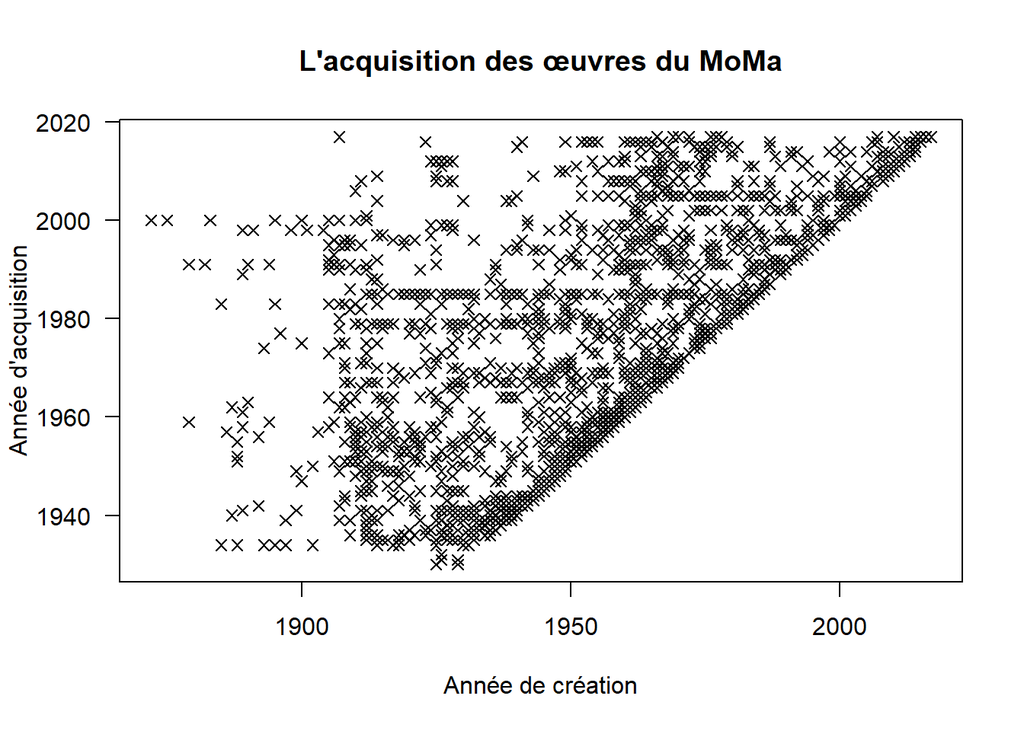

```r
plot(year_acquired~year_created, data = moma,
     pch = 4, las = 1,
     xlab = "Année de création", ylab = "Année d'acquisition",
     main = "L'acquisition des œuvres du MoMa")
```

2. Reprendre le graphique précédent en représentant les points par des ronds pleins et en ajoutant de la transparence à ces derniers.

**Transparence et nuage de points trop dense - utilisation de *package**

Pour rendre plus visible, les points d’un nuage de points quand ces derniers se retrouvent les uns sur les autres, on peut utiliser de la transparence dans la coloration des points.  
Pour cela, installer le package `scales` (à réaliser qu’une seule fois sur votre ordinateur). Après son chargement avec la commande `library(scales)` (à réaliser une fois par session dans RStudio), vous pourrez utiliser la commande `alpha` pour définir la couleur. La commande `alpha` a besoin de deux arguments : la couleur de base et le taux de transparence ou alpha, qui est un nombre entre 0 et 1.

```r
library(scales)
plot(Petal.Width ~ Petal.Length, data = iris,
     pch = 16, col = alpha("black", 0.3))
```

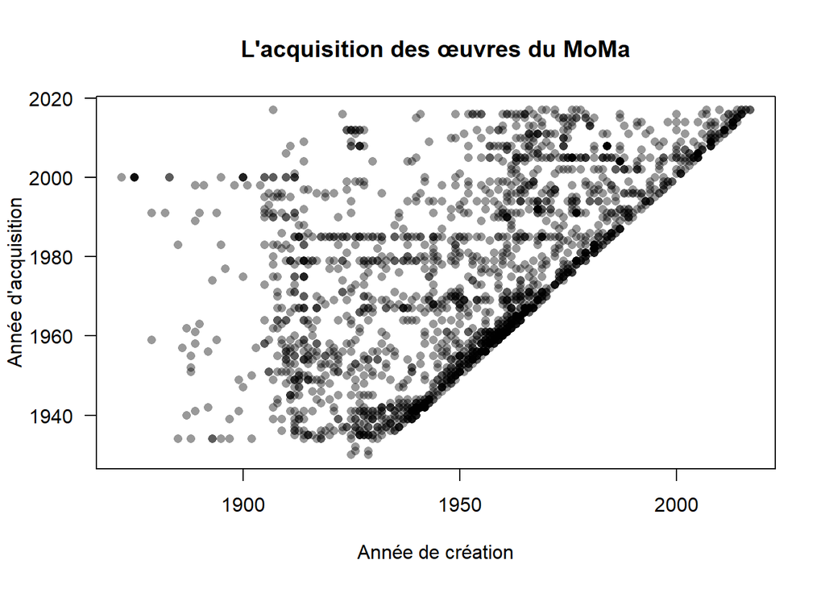

```r
library(scales)
plot(year_acquired~year_created, data = moma,
     pch = 16, col = alpha("black", 0.4),
     las = 1,
     xlab = "Année de création", ylab = "Année d'acquisition",
     main = "L'acquisition des œuvres du MoMa")
```

3. Pour mettre en avant que le musée n’a pas acquis d’œuvre avant que celle-ci soit créée, ajouter la droite d’équation $y = x$.

**Ajout de droite sur un graphique**

La commande `abline()` permet d’ajouter une droite sur un graphique déjà créé.  
Pour cela, on peut spécifier

- soit le coefficient directeur `b` et l’ordonnée à l’origine `a` ;
- soit juste son ordonnée `h`, si la droite est horizontale ;
- soit juste son abscisse `v`, si la droite est verticale.

```r
plot(Petal.Width ~ Petal.Length, data = iris,
     pch = 16, col = alpha("black", 0.3))
abline(b = 0.44, a = -0.36, col = "blue", lty = 2)
```

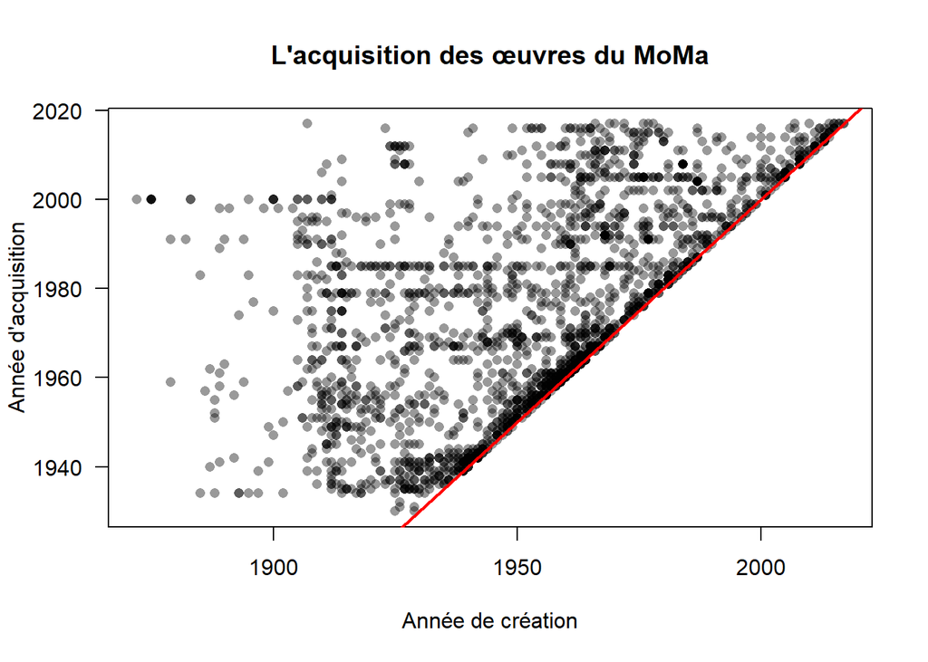

```r
plot(year_acquired~year_created, data = moma,
     pch = 16, col = alpha("black", 0.4),
     las = 1,
     xlab = "Année de création", ylab = "Année d'acquisition",
     main = "L'acquisition des œuvres du MoMa")
abline(a = 0, b = 1, col = "red", lwd = 2)
```

4. Ajouter également une droite mettant en avant que 1985 est l’année ayant eu le plus d’acquisition.

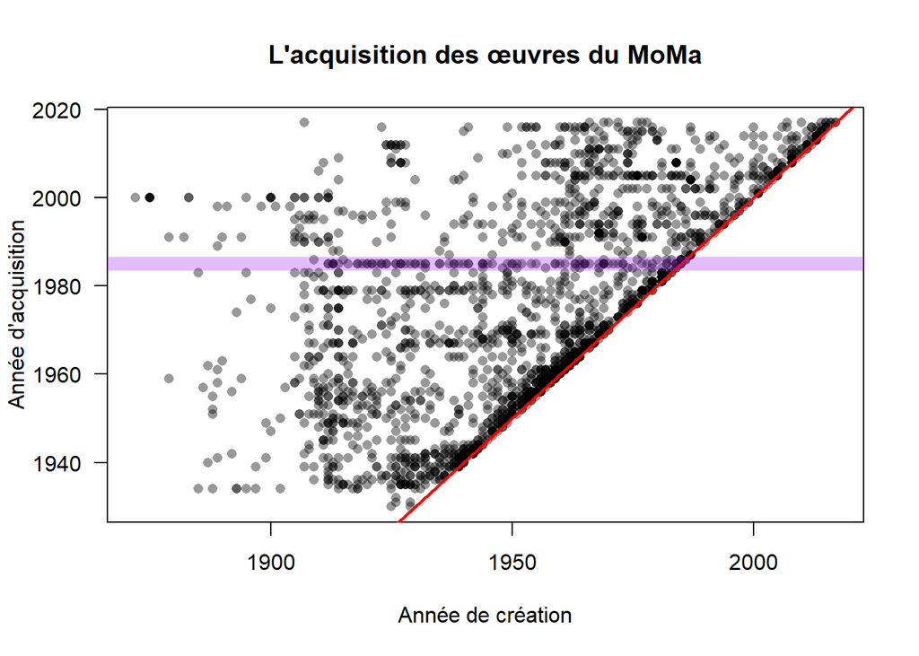

```r
plot(year_acquired~year_created, data = moma,
     pch = 16, col = alpha("black", 0.4),
     las = 1,
     xlab = "Année de création", ylab = "Année d'acquisition",
     main = "L'acquisition des œuvres du MoMa")
abline(a = 0, b = 1, col = "red", lwd = 2)
abline(h = 1985, col = alpha("purple", 0.3), lwd = 10)
```

5. Ajouter du texte sur le graphique pour montrer que cette droite correspond justement à l’année 1985.

**Ajout de texte sur un graphique**

De façon similaire à l’ajout d’une droite sur un graphique, on peut ajouter du texte. Cela se fait avec la commande `text()` et trois arguments principaux : `x` et `y` pour la position de base et `label` pour le texte à écrire. On peut aussi utiliser l’argument `pos` pour spécifier un positionnement par rapport à la postion de base.

```r
plot(Petal.Width ~ Petal.Length, data = iris,
     pch = 16, col = alpha("black", 0.3))
abline(b = 0.44, a = -0.36, col = "blue", lty = 2)
text(label = "La largeur des pétales a tendance \n à augmenter avec leur longueur.",
     x = 5, y = 0.5, col = "blue")
```

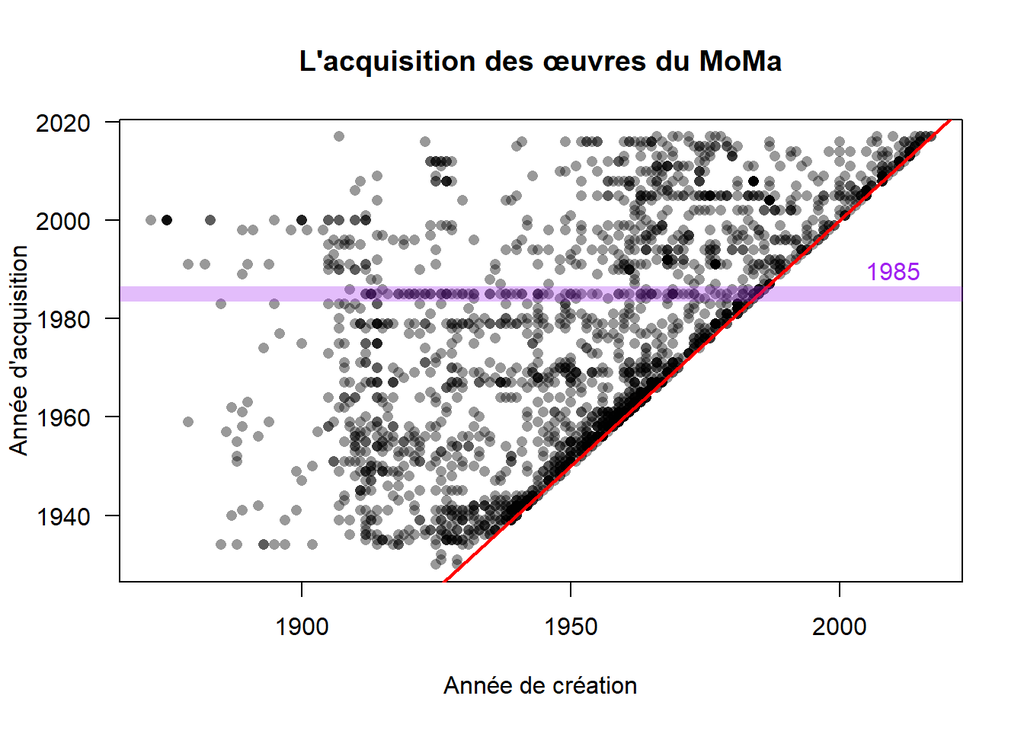

```r
plot(year_acquired~year_created, data = moma,
     pch = 16, col = alpha("black", 0.4),
     las = 1,
     xlab = "Année de création", ylab = "Année d'acquisition",
     main = "L'acquisition des œuvres du MoMa")
abline(a = 0, b = 1, col = "red", lwd = 2)
abline(h = 1985, col = scales::alpha("purple", 0.3), lwd = 10)
text("1985", x = 2010, y = 1985, col = "purple", pos = 3)
```

# La taille des œuvres

Dans cette partie on va se focaliser sur la taille des œuvres.

1. Créer dans le *dataframe* `moma` une variable intitulée `tall_or_wide` qui vaut :
- `tall` si l’œuvre est strictement plus grande que large ;
- `wide` si l’œuvre est strictement plus large que grande ;
- `as tall as wide` si l’œuvre est exactement aussi grande que large.

```r
moma$tall_or_wide <- ifelse(moma$height_cm < moma$width_cm,
                            "wide",
                            ifelse(moma$height_cm > moma$width_cm,
                                  "tall", "as tall as wide"))
```

2. Donner le tableau de contingence du genre de l’artiste principal et de la variable `tall_or_wide`.  
   Quel est le problème ?

```r
table(moma$artist_gender, moma$tall_or_wide)
```

```
         as tall as wide tall wide
  Female              27  131   94
  Male                97  988  906
```

**Variable qualitative ordonnée**

Pour forcer l’ordonnancement des modalités d’une variable qualitative, il faut la créer avec la commande `ordered()` et préciser l’ordre de ses levels avec l’argument `level`.

3. Ordonner les levels de `tall_or_wide` et refaire le tableau de contingence.

```r
moma$tall_or_wide <- ifelse(moma$height_cm < moma$width_cm,
                            "wide",
                            ifelse(moma$height_cm > moma$width_cm,
                                  "tall", "as tall as wide")) |>
  ordered(level = c("wide", "as tall as wide", "tall"))
table(moma$artist_gender, moma$tall_or_wide)
```

```
         wide as tall as wide tall
  Female   94              27  131
  Male    906              97  988
```

4. Réaliser le tableau de contingence du genre de l’artiste principal, de la variable `tall_or_wide` et du fait que l’œuvre soit un cadeau ou non.

```r
table(moma$artist_gender, moma$gift, moma$tall_or_wide)
```

```
, ,  = wide


         FALSE TRUE
  Female    44   50
  Male     406  500

, ,  = as tall as wide


         FALSE TRUE
  Female    16   11
  Male      59   38

, ,  = tall


         FALSE TRUE
  Female    56   75
  Male     499  489
```

**Représentation d’un tableau de contingence de strictement plus de 2 variables**

La commande `table()` peut produire des tableau de contingence de plus de deux dimensions pour en obtenir une représentation *plane*, on peut faire appel à la commande `ftable()`.

```r
table(moma$artist_gender, moma$gift, moma$tall_or_wide) |>
  ftable()
```

```
              wide as tall as wide tall

Female FALSE    44              16   56
       TRUE     50              11   75
Male   FALSE   406              59  499
       TRUE    500              38  489
```

```r
moma$gift2 <- ifelse(moma$gift, "gift", "not a gift")
table(moma$artist_gender, moma$gift2, moma$tall_or_wide) |>
  ftable()
```

```
                   wide as tall as wide tall

Female gift          50              11   75
       not a gift    44              16   56
Male   gift         500              38  489
       not a gift   406              59  499
```